# 北京市喜茶门店数据分析以及针对销量的模型预测

崔士强 PB22151743

2024-06-09

## 背景

本数据记录了北京市喜茶门店的位置，消费，评分，评论数以及附近POI(Points Of Interest)的相关信息，具体属性如下所示

### xicha_data.csv

cityname：门店城市名，均为北京

type：喜茶所属类别，均为餐饮服务;冷饮店;冷饮店

typecode：喜茶所属类别编码，均为50700

adname：喜茶门店所在行政区

name：喜茶门店全名

location：喜茶门店经纬度

cost：喜茶门店人均消费，单位元

rating：喜茶门店人均评分

comments_num：：喜茶门店评论数

### poi_data.csv

uid：爬取数据所用的id

name：POI名

store_name：POI所属的喜茶门店名

location：POI经纬度

address：POI具体地址

area：POI所在行政区

distance：POI与门店距离

tag：POI类别-中文

type：POI类别-英文

price：POI人均消费，单位元

overall_rating：POI人均评分

comment_num：POI评论数

## 数据读取以及预处理

```r
library(tidyverse)
```

首先读取数据，查看前6行

```r
poi_data <- read.csv("poi_data.csv")
head(poi_data)
```

```
##   X                      uid                 name                 store_name
## 1 0 5c6a6b0bae0fc3513be4a6a0           情满四合院 喜茶(北京凯德MALL西直门店)
## 2 1 6835e3a7f68f9157e311031c     新疆饭庄(北京店) 喜茶(北京凯德MALL西直门店)
## 3 2 bb1d38e47ebc3a540c0a706c     天福号(榆树馆店) 喜茶(北京凯德MALL西直门店)
## 4 3 108b1cea97820ab53486f48d 莫斯科餐厅(北展一店) 喜茶(北京凯德MALL西直门店)
## 5 4 373cf757b9131d774354d7ff     肯德基(德宝餐厅) 喜茶(北京凯德MALL西直门店)
## 6 5 5c56edd672313e43a1d23028     吉野家(动物园店) 喜茶(北京凯德MALL西直门店)
##                                location
## 1 {'lat': 39.943058, 'lng': 116.352607}
## 2  {'lat': 39.940506, 'lng': 116.35497}
## 3  {'lat': 39.94283, 'lng': 116.351603}
## 4 {'lat': 39.945963, 'lng': 116.349678}
## 5 {'lat': 39.944787, 'lng': 116.352366}
## 6  {'lat': 39.94454, 'lng': 116.348513}
##                                                   address   area distance
## 1 北京市西城区西直门外大街112号阳光大厦一层地下停车场入口 西城区      101
## 2                           北京市西城区车公庄大街一号1号 西城区      287
## 3          北京市西城区展览馆路榆树馆15号楼近西直门外南路 西城区       99
## 4                           北京市西城区西直门外大街135号 西城区      481
## 5                    北京市西城区西直门外大街德宝新园14号 西城区      291
## 6                           北京市西城区西直门外大街137号 西城区      422
##               tag  type price overall_rating comment_num
## 1     美食;中餐厅 cater 111.0            4.7           2
## 2     美食;中餐厅 cater  96.0            4.5         168
## 3       美食;其他 cater  52.0            3.7          71
## 4   美食;外国餐厅 cater  47.0            4.5         200
## 5 美食;小吃快餐店 cater  50.0            3.5          14
## 6 美食;小吃快餐店 cater  32.0            4.2          10
```

```r
xicha_data <- read.csv("xicha_data.csv")
head(xicha_data)
```

```
##                                                            address cityname
## 1                     西直门外大街1号西环广场凯德Mall西直门1层49号   北京市
## 2                                北三环东路36号楼E栋裙房L1层10单元   北京市
## 3                                       槐房西路9号院5号楼一层01号   北京市
## 4                       安泰大街9号院的中粮祥云小镇南区3-104号商铺   北京市
## 5 西北旺东路10号院东区5号楼中关村软件园互联网创新中心一层114号铺位   北京市
## 6   丽泽路16号院1号楼龙湖·北京丽泽天街商场(A-1F-16b,A-1F-17)号房屋   北京市
##                     type typecode adname                       name
## 1 餐饮服务;冷饮店;冷饮店    50700 西城区 喜茶(北京凯德MALL西直门店)
## 2 餐饮服务;冷饮店;冷饮店    50700 东城区     喜茶(北京环球贸易中心)
## 3 餐饮服务;冷饮店;冷饮店    50700 丰台区 喜茶(北京丰台大悦春风里店)
## 4 餐饮服务;冷饮店;冷饮店    50700 顺义区   喜茶(北京中粮祥云小镇店)
## 5 餐饮服务;冷饮店;冷饮店    50700 海淀区   喜茶(北京中关村软件园店)
## 6 餐饮服务;冷饮店;冷饮店    50700 丰台区   喜茶(北京丽泽龙湖天街店)
##               location cost rating comments_num
## 1 116.352384,39.942165   NA    4.7          306
## 2 116.410974,39.965903   37    4.6          178
## 3 116.364594,39.810036   NA    4.4           NA
## 4 116.536817,40.088242   35    4.8          537
## 5 116.280687,40.047585   28    4.6          215
## 6 116.334609,39.865891   29    4.8          453
```

删除不需要的属性

```r
xicha_data <- xicha_data %>%
  # 删除cityname, type, typecode列
  select(-cityname, -type, -typecode) %>%
  # 将经纬度数据分成两列
  separate(location, into = c("longitude", "latitude"), sep = ",", convert = TRUE)

poi_data <- poi_data %>%
  # 删除uid, X列
  select(-uid, -X) %>%
  # 将price列转换为数值类型
  mutate(price = as.numeric(price))
```

在对`NA`进行处理前，先统计共有多少行含有`NA`，再决定处理方法

```r
na_count_poi = sum(complete.cases(poi_data) == FALSE)
na_count_xicha = sum(complete.cases(xicha_data) == FALSE)

cat("POI数据集中含有NA的行数：", na_count_poi, "\n")
```

```
## POI数据集中含有NA的行数： 34283
```

```r
cat("喜茶数据集中含有NA的行数：", na_count_xicha, "\n")
```

```
## 喜茶数据集中含有NA的行数： 7
```

考虑到含`NA`的行过多，用均值、中位数、众数等填充可能会影响分析准确度，故暂时保留，后面进行数据分析时使用`na.rm = TRUE`参数在计算统计指标时排除这些缺失值，从而在保持数据完整性的同时，避免潜在的误导性分析。

查看当前数据情况

```r
str(xicha_data)
```

```
## 'data.frame':    68 obs. of  8 variables:
##  $ address     : chr  "西直门外大街1号西环广场凯德Mall西直门1层49号" "北三环东路36号楼E栋裙房L1层10单元" "槐房西路9号院5号楼一层01号" "安泰大街9号院的中粮祥云小镇南区3-104号商铺" ...
##  $ adname      : chr  "西城区" "东城区" "丰台区" "顺义区" ...
##  $ name        : chr  "喜茶(北京凯德MALL西直门店)" "喜茶(北京环球贸易中心)" "喜茶(北京丰台大悦春风里店)" "喜茶(北京中粮祥云小镇店)" ...
##  $ longitude   : num  116 116 116 117 116 ...
##  $ latitude    : num  39.9 40 39.8 40.1 40 ...
##  $ cost        : num  NA 37 NA 35 28 29 26 27 NA 32 ...
##  $ rating      : num  4.7 4.6 4.4 4.8 4.6 4.8 4.7 4.7 4.4 4.8 ...
##  $ comments_num: num  306 178 NA 537 215 453 209 482 71 462 ...
```

```r
summary(xicha_data)
```

```
##    address             adname              name             longitude
##  Length:68          Length:68          Length:68          Min.   :116.1
##  Class :character   Class :character   Class :character   1st Qu.:116.3
##  Mode  :character   Mode  :character   Mode  :character   Median :116.4
##                                                           Mean   :116.4
##                                                           3rd Qu.:116.5
##                                                           Max.   :116.6
##
##     latitude          cost           rating       comments_num
##  Min.   :39.73   Min.   :16.00   Min.   :4.400   Min.   :   71
##  1st Qu.:39.90   1st Qu.:29.00   1st Qu.:4.675   1st Qu.:  453
##  Median :39.92   Median :30.00   Median :4.700   Median :  704
##  Mean   :39.93   Mean   :30.73   Mean   :4.704   Mean   : 1774
##  3rd Qu.:39.98   3rd Qu.:32.50   3rd Qu.:4.800   3rd Qu.: 1574
##  Max.   :40.10   Max.   :50.00   Max.   :4.900   Max.   :13253
##                  NA's   :5                       NA's   :3
```

发现有一些指标中位数与均值相差较大，因此进行进一步检查。

对`xicha_data`当中的数据进行偏度检查

```r
library(e1071)

# cost的偏度
cost_skewness <- skewness(xicha_data$cost, na.rm = TRUE)
print(paste("Cost Skewness:", cost_skewness))
```

```
## [1] "Cost Skewness: 0.760242938088597"
```

```r
# rating的偏度
rating_skewness <- skewness(xicha_data$rating, na.rm = TRUE)
print(paste("Rating Skewness:", rating_skewness))
```

```
## [1] "Rating Skewness: -0.92136793757793"
```

```r
# comments_num的偏度
comments_skewness <- skewness(xicha_data$comments_num, na.rm = TRUE)
print(paste("Comments Number Skewness:", comments_skewness))
```

```
## [1] "Comments Number Skewness: 2.85796702880693"
```

发现评论数量极度右偏，看一看极端数据的具体情况

```r
# 找到评论数最高的5行
top_comments <- xicha_data %>%
  arrange(desc(comments_num)) %>%
  slice_head(n = 5)

print(top_comments)
```

```
##                                       address adname                     name
## 1       三里屯路19号院6号楼S6-11a单元,MAC对面 朝阳区 喜茶(北京三里屯太古里店)
## 2              朝阳北路101号朝阳大悦城1层28号 朝阳区       喜茶(朝阳大悦城店)
## 3 中关村大街19号新中关大厦1层L103号北门入口处 海淀区 喜茶(新中关购物中心DP店)
## 4  崇文门外大街18号国瑞购物中心1幢F1-27号商铺 东城区   喜茶(北京崇文门国瑞店)
## 5              西单北大街130号君太百货2楼f-08 西城区   喜茶(北京君太百货DP店)
##   longitude latitude cost rating comments_num
## 1  116.4547 39.93513   34    4.9        13253
## 2  116.5191 39.92408   32    4.8        13178
## 3  116.3155 39.97846   25    4.9         7670
## 4  116.4193 39.89899   30    4.8         6338
## 5  116.3734 39.90921   28    4.8         5724
```

评论数极高的门店位于著名商业综合体，因此认为不属于异常值。

再来看`poi_data`

```r
str(poi_data)
```

```
## 'data.frame':    39798 obs. of  11 variables:
##  $ name          : chr  "情满四合院" "新疆饭庄(北京店)" "天福号(榆树馆店)" "莫斯科餐厅(北展一店)" ...
##  $ store_name    : chr  "喜茶(北京凯德MALL西直门店)" "喜茶(北京凯德MALL西直门店)" "喜茶(北京凯德MALL西直门店)" "喜茶(北京凯德MALL西直门店)" ...
##  $ location      : chr  "{'lat': 39.943058, 'lng': 116.352607}" "{'lat': 39.940506, 'lng': 116.35497}" "{'lat': 39.94283, 'lng': 116.351603}" "{'lat': 39.945963, 'lng': 116.349678}" ...
##  $ address       : chr  "北京市西城区西直门外大街112号阳光大厦一层地下停车场入口" "北京市西城区车公庄大街一号1号" "北京市西城区展览馆路榆树馆15号楼近西直门外南路" "北京市西城区西直门外大街135号" ...
##  $ area          : chr  "西城区" "西城区" "西城区" "西城区" ...
##  $ distance      : int  101 287 99 481 291 422 544 124 467 83 ...
##  $ tag           : chr  "美食;中餐厅" "美食;中餐厅" "美食;其他" "美食;外国餐厅" ...
##  $ type          : chr  "cater" "cater" "cater" "cater" ...
##  $ price         : num  111 96 52 47 50 32 43 25 253 NA ...
##  $ overall_rating: num  4.7 4.5 3.7 4.5 3.5 4.2 2.7 3.9 4.7 3.3 ...
##  $ comment_num   : int  2 168 71 200 14 10 25 50 0 0 ...
```

```r
summary(poi_data)
```

```
##      name            store_name          location           address
##  Length:39798       Length:39798       Length:39798       Length:39798
##  Class :character   Class :character   Class :character   Class :character
##  Mode  :character   Mode  :character   Mode  :character   Mode  :character
##
##
##
##
##      area              distance          tag                type
##  Length:39798       Min.   :   8.0   Length:39798       Length:39798
##  Class :character   1st Qu.: 424.0   Class :character   Class :character
##  Mode  :character   Median : 753.0   Mode  :character   Mode  :character
##                     Mean   : 949.4
##                     3rd Qu.:1360.0
##                     Max.   :2999.0
##
##      price        overall_rating   comment_num
##  Min.   :    -1   Min.   :0.000   Min.   :  0.00
##  1st Qu.:    27   1st Qu.:0.000   1st Qu.:  0.00
##  Median :    86   Median :3.500   Median :  1.00
##  Mean   :   336   Mean   :2.507   Mean   : 12.18
##  3rd Qu.:   175   3rd Qu.:4.500   3rd Qu.:  7.00
##  Max.   :148966   Max.   :5.000   Max.   :200.00
##  NA's   :33732    NA's   :17254   NA's   :18620
```

`price`明显有异常值，查看最大和最小的10行

```r
lowest_prices <- poi_data %>%
  arrange(price) %>%
  slice_head(n = 10)

highest_prices <- poi_data %>%
  arrange(desc(price)) %>%
  slice_head(n = 10)

print(lowest_prices)
```

```
##                        name                 store_name
## 1                  震旦禅艺     喜茶(北京金源新燕莎店)
## 2        盒马鲜生(西直门店) 喜茶(北京凯德MALL西直门店)
## 3            家乐福(方圆店) 喜茶(北京凯德MALL西直门店)
## 4        顺天府超市(国英店) 喜茶(北京凯德MALL西直门店)
## 5  新华书店总店(城市书房店) 喜茶(北京凯德MALL西直门店)
## 6        便利蜂(阳光大厦店) 喜茶(北京凯德MALL西直门店)
## 7      好邻居便利店(车西店) 喜茶(北京凯德MALL西直门店)
## 8      优胜教育(车公庄校区) 喜茶(北京凯德MALL西直门店)
## 9  樱花国际日语(西直门分部) 喜茶(北京凯德MALL西直门店)
## 10         北京大学人民医院 喜茶(北京凯德MALL西直门店)
##                                 location
## 1  {'lat': 39.956232, 'lng': 116.292015}
## 2  {'lat': 39.943375, 'lng': 116.352469}
## 3  {'lat': 39.944815, 'lng': 116.336317}
```

[output cut: 29 more lines]

```r
print(highest_prices)
```

```
##                                name                 store_name
## 1              馨月汇(北京)月子会所         喜茶(北京颐堤港店)
## 2                    庄胜二期游泳馆       喜茶(北京前门大街店)
## 3                  北京市复兴商业城 喜茶(北京金融街购物中心店)
## 4  立方庭国际游泳健身会所(立方庭店)               喜茶(融科店)
## 5                    北京和睦家医院         喜茶(北京颐堤港店)
## 6      爱玛家母婴中心(母婴护理会所)   喜茶(北京中粮祥云小镇店)
## 7      北京思语众合教育咨询有限公司       喜茶(北京朝阳门外店)
## 8                北京新世纪妇儿医院     喜茶(北京望京麒麟社店)
## 9                      环球贸易中心     喜茶(北京环球贸易中心)
## 10                     方恒购物中心       喜茶(北京浦项中心店)
##                                 location
## 1   {'lat': 39.97975, 'lng': 116.489881}
## 2  {'lat': 39.903782, 'lng': 116.388078}
## 3  {'lat': 39.912523, 'lng': 116.356102}
```

[output cut: 40 more lines]

去除`price`为负的行

```r
poi_data <- poi_data %>%
  filter(price >= 0 | is.na(price))
```

## 初步分析

下面对一些数据进行基本的统计

```r
xicha_stats <- xicha_data %>%
  summarise(
    Average_Cost = mean(cost, na.rm = TRUE),
    Average_Rating = mean(rating, na.rm = TRUE),
  )

print(xicha_stats)
```

```
##   Average_Cost Average_Rating
## 1     30.73016       4.704412
```

```r
poi_stats <- poi_data %>%
  summarise(
    Average_Price = mean(price, na.rm = TRUE),
    Average_Rating = mean(overall_rating, na.rm = TRUE),
  )

print(poi_stats)
```

```
##   Average_Price Average_Rating
## 1      336.0183       2.507026
```

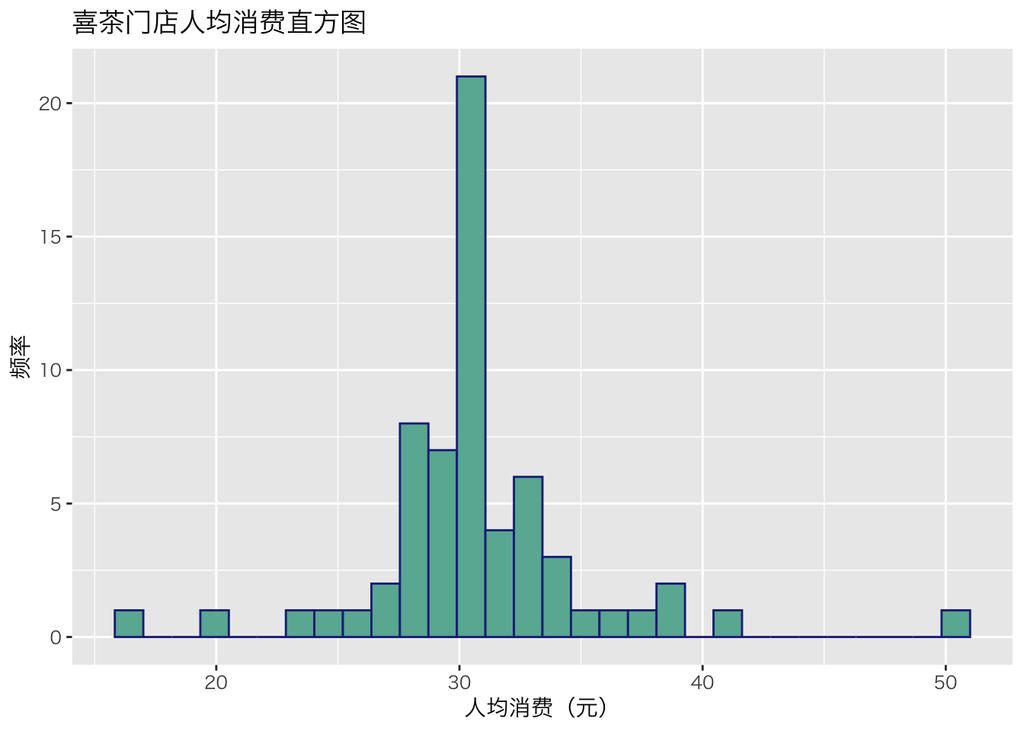

```r
# 绘制 cost 的直方图
ggplot(xicha_data, aes(x = cost)) +
  geom_histogram(bins = 30, fill = "#69b3a2", color = "#1f2d86") +
  ggtitle("喜茶门店人均消费直方图") +
  xlab("人均消费（元）") +
  ylab("频率") +
  theme(text = element_text(family = "Hiragino Sans GB"))
```

可以看到人均消费非常集中，在30元左右

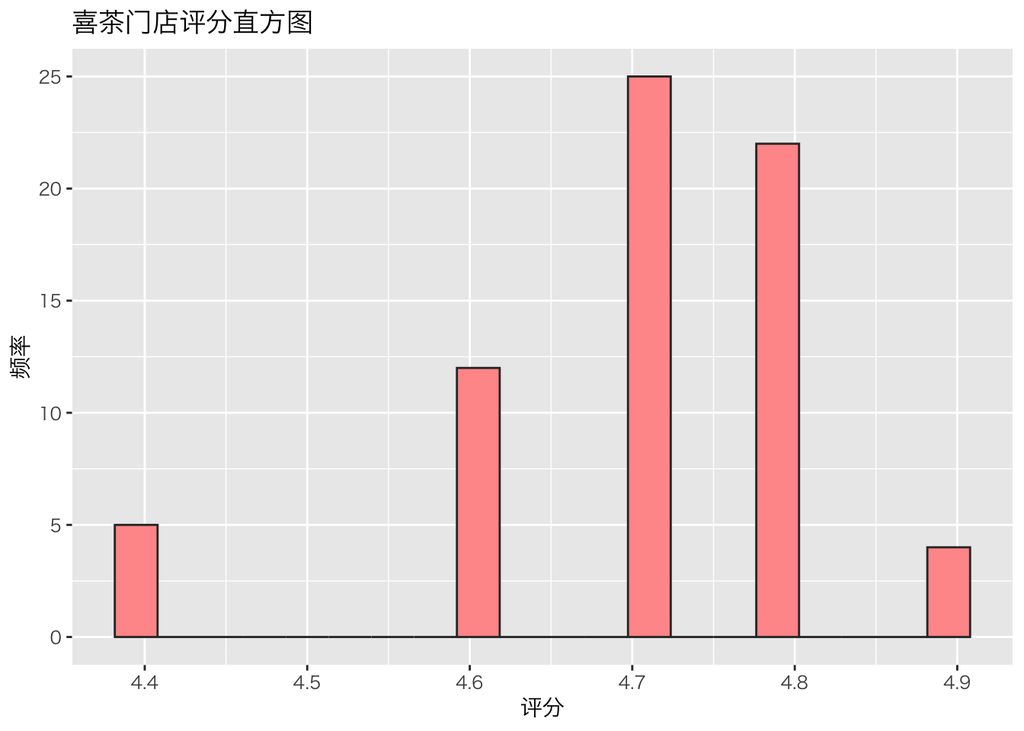

```r
# 绘制 rating 的直方图
ggplot(xicha_data, aes(x = rating)) +
  geom_histogram(bins = 20, fill = "#ff9999", color = "#333333") +
  ggtitle("喜茶门店评分直方图") +
  xlab("评分") +
  ylab("频率") +
  theme(text = element_text(family = "Hiragino Sans GB"))
```

评分均处于较高水平。

数据中没有关于销量的信息，而评分并不由选址以及POI这些数据集侧重的因素决定，因此在后续分析中把评论数作为销量的代理指标，接下来看评论数的分布

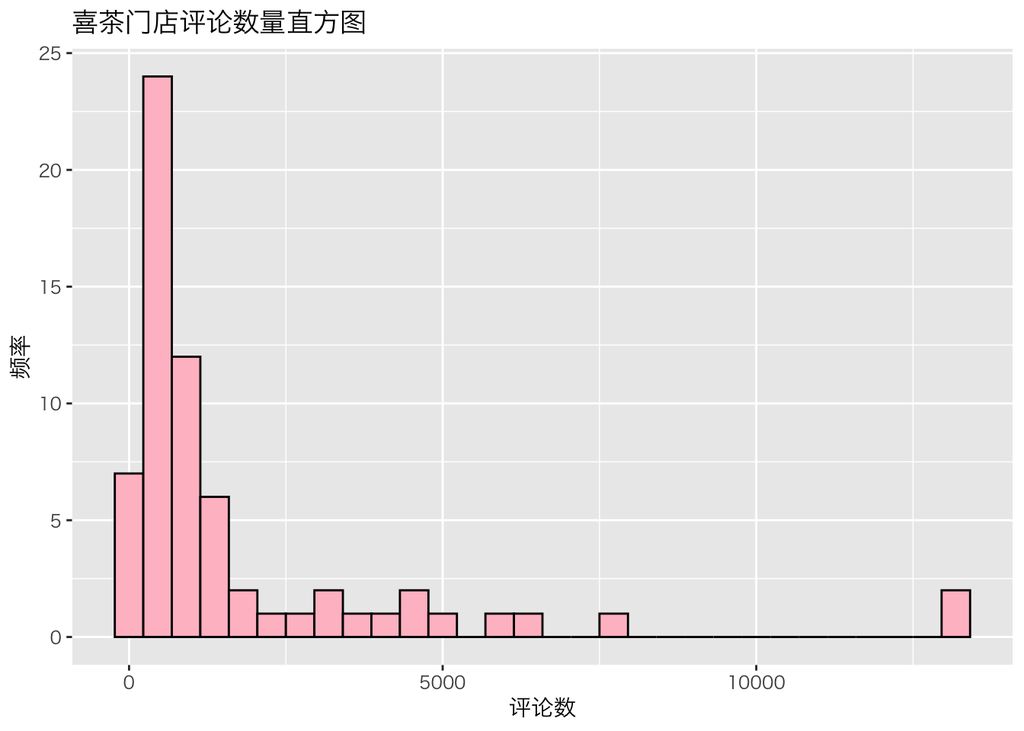

```r
# 绘制 comments_num 的直方图
ggplot(xicha_data, aes(x = comments_num)) +
  geom_histogram(bins = 30, fill = "#ffc0cb", color = "#000000") +
  ggtitle("喜茶门店评论数量直方图") +
  xlab("评论数") +
  ylab("频率") +
  theme(text = element_text(family = "Hiragino Sans GB"))
```

评论数大部分集中在1000以下，少数具有远高于中位数的值。

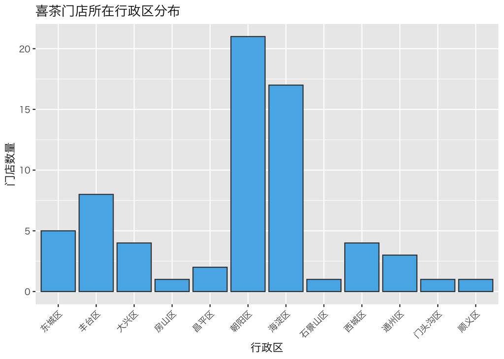

```r
# 绘制 adname 列的条形图
ggplot(xicha_data, aes(x = adname)) +
  geom_bar(fill = "#56B4E9", color = "#404040") +
  ggtitle("喜茶门店所在行政区分布") +
  xlab("行政区") +
  ylab("门店数量") +
  theme(text = element_text(family = "Hiragino Sans GB"),
        axis.text.x = element_text(angle = 45, hjust = 1))  # X轴标签倾斜
```

```r
library(leaflet)

leaflet(xicha_data) %>%
  addTiles() %>%
  addCircles(lng = ~longitude, lat = ~latitude, weight = 1,
             radius = 50, color = "#FF0000", fillOpacity = 0.8,
             popup = ~paste("门店名:", name, "<br>", "评分:", rating))
```

[interactive chart not shown]

注意到POI有不同tag和type，可以对这两个属性进行统计

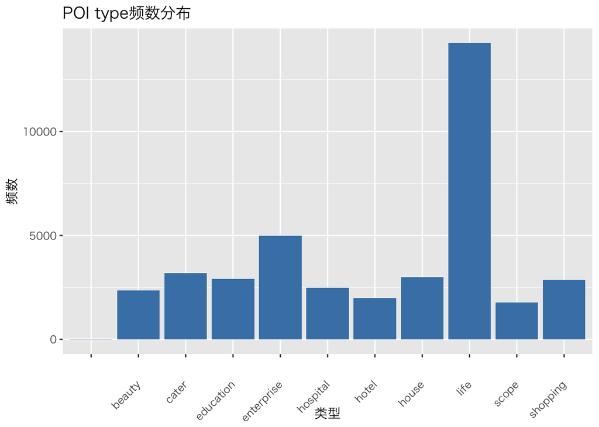

```r
# 绘制type列的条形图
ggplot(poi_data, aes(x = type)) +
  geom_bar(fill = "steelblue") +
  labs(title = "POI type频数分布", x = "类型", y = "频数") +
  theme(axis.text.x = element_text(angle = 45, hjust = 1, vjust = 0.5), # 旋转X轴标签以便阅读
        text = element_text(family = "Hiragino Sans GB"))
```

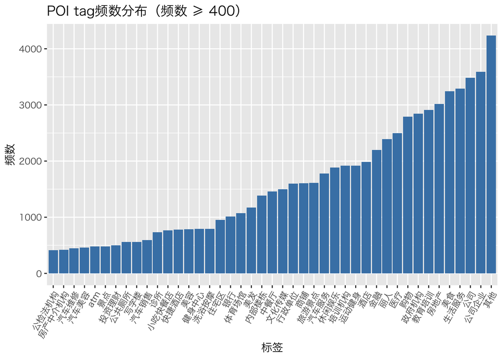

```r
# 拆分tag列
tags_split <- poi_data %>%
  mutate(tags = strsplit(as.character(tag), ";")) %>%
  unnest_longer(col = tags)

# 统计每个标签的频数，并过滤频数小于400的标签
tag_counts <- tags_split %>%
  group_by(tags) %>%
  summarise(count = n(), .groups = 'drop') %>%
  filter(count >= 400) %>%  # 过滤
  arrange(desc(count))

# 绘制tag条形图
ggplot(tag_counts, aes(x = reorder(tags, count), y = count)) +
  geom_bar(stat = "identity", fill = "steelblue") +
  labs(title = "POI tag频数分布（频数 ≥ 400）", x = "标签", y = "频数") +
  theme(axis.text.x = element_text(angle = 60, hjust = 1),
        text = element_text(family = "Hiragino Sans GB"))
```

## 深入分析

上面是一些笼统的统计数据，接下来我们试图分析更具体，更有商业价值的数据。在此之前，先对平均分进行处理。 考虑到评论数较少时平均分并不能反映真实情况，这里采用贝叶斯平均。

```r
# 计算xicha_data的平均评分和评论数
avg_score_xicha <- mean(xicha_data$rating, na.rm = TRUE)
avg_num_xicha <- mean(xicha_data$comments_num, na.rm = TRUE)

# 计算贝叶斯平均
xicha_data$bayesian_avg <- ((avg_score_xicha * avg_num_xicha) + (xicha_data$rating * xicha_data$comments_num)) / (avg_num_xicha + xicha_data$comments_num)

# 查看更新后的数据
head(xicha_data)
```

```
##                                                            address adname
## 1                     西直门外大街1号西环广场凯德Mall西直门1层49号 西城区
## 2                                北三环东路36号楼E栋裙房L1层10单元 东城区
## 3                                       槐房西路9号院5号楼一层01号 丰台区
## 4                       安泰大街9号院的中粮祥云小镇南区3-104号商铺 顺义区
## 5 西北旺东路10号院东区5号楼中关村软件园互联网创新中心一层114号铺位 海淀区
## 6   丽泽路16号院1号楼龙湖·北京丽泽天街商场(A-1F-16b,A-1F-17)号房屋 丰台区
##                         name longitude latitude cost rating comments_num
## 1 喜茶(北京凯德MALL西直门店)  116.3524 39.94217   NA    4.7          306
## 2     喜茶(北京环球贸易中心)  116.4110 39.96590   37    4.6          178
## 3 喜茶(北京丰台大悦春风里店)  116.3646 39.81004   NA    4.4           NA
## 4   喜茶(北京中粮祥云小镇店)  116.5368 40.08824   35    4.8          537
## 5   喜茶(北京中关村软件园店)  116.2807 40.04758   28    4.6          215
## 6   喜茶(北京丽泽龙湖天街店)  116.3346 39.86589   29    4.8          453
##   bayesian_avg
## 1     4.703763
## 2     4.694891
## 3           NA
## 4     4.726623
## 5     4.693126
## 6     4.723855
```

```r
# 计算poi_data的平均评分和评论数
avg_score_poi <- mean(poi_data$overall_rating, na.rm = TRUE)
avg_num_poi <- mean(poi_data$comment_num, na.rm = TRUE)

# 计算贝叶斯平均
poi_data$bayesian_avg <- ((avg_score_poi * avg_num_poi * 0.5) + (poi_data$overall_rating * poi_data$comment_num)) / (0.5 * avg_num_poi + poi_data$comment_num)

# 查看更新后的数据
head(poi_data)
```

```
##                   name                 store_name
## 1           情满四合院 喜茶(北京凯德MALL西直门店)
## 2     新疆饭庄(北京店) 喜茶(北京凯德MALL西直门店)
## 3     天福号(榆树馆店) 喜茶(北京凯德MALL西直门店)
## 4 莫斯科餐厅(北展一店) 喜茶(北京凯德MALL西直门店)
## 5     肯德基(德宝餐厅) 喜茶(北京凯德MALL西直门店)
## 6     吉野家(动物园店) 喜茶(北京凯德MALL西直门店)
##                                location
## 1 {'lat': 39.943058, 'lng': 116.352607}
## 2  {'lat': 39.940506, 'lng': 116.35497}
## 3  {'lat': 39.94283, 'lng': 116.351603}
## 4 {'lat': 39.945963, 'lng': 116.349678}
## 5 {'lat': 39.944787, 'lng': 116.352366}
## 6  {'lat': 39.94454, 'lng': 116.348513}
##                                                   address   area distance
## 1 北京市西城区西直门外大街112号阳光大厦一层地下停车场入口 西城区      101
## 2                           北京市西城区车公庄大街一号1号 西城区      287
## 3          北京市西城区展览馆路榆树馆15号楼近西直门外南路 西城区       99
## 4                           北京市西城区西直门外大街135号 西城区      481
## 5                    北京市西城区西直门外大街德宝新园14号 西城区      291
## 6                           北京市西城区西直门外大街137号 西城区      422
##               tag  type price overall_rating comment_num bayesian_avg
## 1     美食;中餐厅 cater   111            4.7           2     3.049183
## 2     美食;中餐厅 cater    96            4.5         168     4.430284
## 3       美食;其他 cater    52            3.7          71     3.605759
## 4   美食;外国餐厅 cater    47            4.5         200     4.441109
## 5 美食;小吃快餐店 cater    50            3.5          14     3.199000
## 6 美食;小吃快餐店 cater    32            4.2          10     3.559228
```

之后我们把两个数据框合并，以便接下来的分析。

```r
# 为poi_data中除store_name外的所有列添加前缀
poi_data_prefixed <- poi_data %>%
  rename_with(.fn = ~paste0("poi_", .), .cols = -store_name)

# 合并数据框
combined_data <- xicha_data %>%
  left_join(poi_data_prefixed, by = c("name" = "store_name"))

# 查看合并后的数据框
print(head(combined_data))
```

```
##                                        address adname
## 1 西直门外大街1号西环广场凯德Mall西直门1层49号 西城区
## 2 西直门外大街1号西环广场凯德Mall西直门1层49号 西城区
## 3 西直门外大街1号西环广场凯德Mall西直门1层49号 西城区
## 4 西直门外大街1号西环广场凯德Mall西直门1层49号 西城区
## 5 西直门外大街1号西环广场凯德Mall西直门1层49号 西城区
## 6 西直门外大街1号西环广场凯德Mall西直门1层49号 西城区
##                         name longitude latitude cost rating comments_num
## 1 喜茶(北京凯德MALL西直门店)  116.3524 39.94217   NA    4.7          306
## 2 喜茶(北京凯德MALL西直门店)  116.3524 39.94217   NA    4.7          306
## 3 喜茶(北京凯德MALL西直门店)  116.3524 39.94217   NA    4.7          306
## 4 喜茶(北京凯德MALL西直门店)  116.3524 39.94217   NA    4.7          306
## 5 喜茶(北京凯德MALL西直门店)  116.3524 39.94217   NA    4.7          306
## 6 喜茶(北京凯德MALL西直门店)  116.3524 39.94217   NA    4.7          306
##   bayesian_avg             poi_name                          poi_location
```

[output cut: 27 more lines]

```r
str(combined_data)
```

```
## 'data.frame':    39797 obs. of  20 variables:
##  $ address           : chr  "西直门外大街1号西环广场凯德Mall西直门1层49号" "西直门外大街1号西环广场凯德Mall西直门1层49号" "西直门外大街1号西环广场凯德Mall西直门1层49号" "西直门外大街1号西环广场凯德Mall西直门1层49号" ...
##  $ adname            : chr  "西城区" "西城区" "西城区" "西城区" ...
##  $ name              : chr  "喜茶(北京凯德MALL西直门店)" "喜茶(北京凯德MALL西直门店)" "喜茶(北京凯德MALL西直门店)" "喜茶(北京凯德MALL西直门店)" ...
##  $ longitude         : num  116 116 116 116 116 ...
##  $ latitude          : num  39.9 39.9 39.9 39.9 39.9 ...
##  $ cost              : num  NA NA NA NA NA NA NA NA NA NA ...
##  $ rating            : num  4.7 4.7 4.7 4.7 4.7 4.7 4.7 4.7 4.7 4.7 ...
##  $ comments_num      : num  306 306 306 306 306 306 306 306 306 306 ...
##  $ bayesian_avg      : num  4.7 4.7 4.7 4.7 4.7 ...
##  $ poi_name          : chr  "情满四合院" "新疆饭庄(北京店)" "天福号(榆树馆店)" "莫斯科餐厅(北展一店)" ...
##  $ poi_location      : chr  "{'lat': 39.943058, 'lng': 116.352607}" "{'lat': 39.940506, 'lng': 116.35497}" "{'lat': 39.94283, 'lng': 116.351603}" "{'lat': 39.945963, 'lng': 116.349678}" ...
##  $ poi_address       : chr  "北京市西城区西直门外大街112号阳光大厦一层地下停车场入口" "北京市西城区车公庄大街一号1号" "北京市西城区展览馆路榆树馆15号楼近西直门外南路" "北京市西城区西直门外大街135号" ...
##  $ poi_area          : chr  "西城区" "西城区" "西城区" "西城区" ...
##  $ poi_distance      : int  101 287 99 481 291 422 544 124 467 83 ...
##  $ poi_tag           : chr  "美食;中餐厅" "美食;中餐厅" "美食;其他" "美食;外国餐厅" ...
##  $ poi_type          : chr  "cater" "cater" "cater" "cater" ...
##  $ poi_price         : num  111 96 52 47 50 32 43 25 253 NA ...
##  $ poi_overall_rating: num  4.7 4.5 3.7 4.5 3.5 4.2 2.7 3.9 4.7 3.3 ...
##  $ poi_comment_num   : int  2 168 71 200 14 10 25 50 0 0 ...
##  $ poi_bayesian_avg  : num  3.05 4.43 3.61 4.44 3.2 ...
```

```r
selected_data <- combined_data %>%
  select(name, comments_num, bayesian_avg, poi_distance, poi_type) %>%
  na.omit()
summary(selected_data)
```

```
##      name            comments_num    bayesian_avg    poi_distance
##  Length:38166       Min.   :   71   Min.   :4.656   Min.   :   8.0
##  Class :character   1st Qu.:  440   1st Qu.:4.702   1st Qu.: 423.0
##  Mode  :character   Median :  699   Median :4.703   Median : 748.0
##                     Mean   : 1704   Mean   :4.722   Mean   : 944.7
##                     3rd Qu.: 1478   3rd Qu.:4.745   3rd Qu.:1351.0
##                     Max.   :13253   Max.   :4.877   Max.   :2999.0
##    poi_type
##  Length:38166
##  Class :character
##  Mode  :character
##
##
##
```

观察数据可以发现，tag的多样性非常丰富，考虑到处理成独热编码后可能导致的数据框尺度大幅增长以及数据不足，选择type进行分析。

首先将`poi_type`列进行独热编码，并与原始数据合并

```r
selected_data <- selected_data %>%
  mutate(poi_type = as.factor(poi_type)) %>%
  group_by(name, poi_type) %>%
  mutate(count = n()) %>%
  ungroup() %>%
  pivot_wider(names_from = poi_type, values_from = c(count, poi_distance),
              names_sep = "_", values_fn = list(count = mean, poi_distance = mean),
              values_fill = list(count = 0, poi_distance = NA))

store_features <- selected_data %>%
  group_by(name) %>%
  summarise(across(starts_with("count"), sum, na.rm = TRUE),
            across(starts_with("poi_distance"), mean, na.rm = TRUE),
            Comments_Num = first(comments_num)) %>%
  select(-poi_distance_, -count_) %>%
  na.omit()
print(head(store_features))
```

```
## # A tibble: 6 × 22
##   name        count_cater count_hotel count_enterprise count_shopping count_life
##   <chr>             <dbl>       <dbl>            <dbl>          <dbl>      <dbl>
## 1 喜茶(上地…           56          25               79             28        233
## 2 喜茶(东直…           59          49               98             50        271
## 3 喜茶(北京a…          52          43               85             32        232
## 4 喜茶(北京…           57          28               65             44        153
## 5 喜茶(北京…           49          27               65             43        218
## 6 喜茶(北京…           52           9               58             48        164
## # ℹ 16 more variables: count_hospital <dbl>, count_beauty <dbl>,
## #   count_education <dbl>, count_scope <dbl>, count_house <dbl>,
## #   poi_distance_cater <dbl>, poi_distance_hotel <dbl>,
## #   poi_distance_enterprise <dbl>, poi_distance_shopping <dbl>,
## #   poi_distance_life <dbl>, poi_distance_hospital <dbl>,
## #   poi_distance_beauty <dbl>, poi_distance_education <dbl>,
## #   poi_distance_scope <dbl>, poi_distance_house <dbl>, Comments_Num <dbl>
```

进行标准化

```r
# 数据标准化
normalized_data <- store_features %>%
  select(starts_with("poi_distance"), starts_with("count")) %>%  # 聚类特征
  scale() # 标准化特征

# 查看标准化后的数据
head(normalized_data)
```

```
##      poi_distance_cater poi_distance_hotel poi_distance_enterprise
## [1,]          0.5244135           1.011525               0.8981689
## [2,]         -0.8092307          -0.546679              -0.9290816
## [3,]         -0.5139753          -1.286617              -0.4833876
## [4,]         -1.1721349          -1.484566              -1.0600137
## [5,]         -0.2292456           1.453398               0.1406917
## [6,]          0.1390595           0.215087              -0.9442105
##      poi_distance_shopping poi_distance_life poi_distance_hospital
## [1,]             0.7597140         0.6918406             1.2048743
## [2,]            -0.6806651        -0.7570844            -0.3863625
## [3,]            -0.4177260        -0.3686360            -0.1513987
## [4,]            -0.6683084        -1.4007352            -1.1597211
## [5,]             0.2478885         0.2367874             0.1875017
## [6,]             2.4409355         1.3354689             1.6498578
##      poi_distance_beauty poi_distance_education poi_distance_scope
```

[output cut: 27 more lines]

进行k-means聚类分析，聚类数设为4

```r
library(factoextra)
k <- 4  # 聚类数
final_cluster <- kmeans(normalized_data, centers = k, nstart = 25)

# 将聚类结果添加到原始数据中
store_features$cluster <- as.factor(final_cluster$cluster)

# 查看聚类结果
aggregate(Comments_Num ~ cluster, data = store_features, mean)
```

```
##   cluster Comments_Num
## 1       1      875.400
## 2       2     2957.158
## 3       3      918.500
## 4       4     1596.043
```

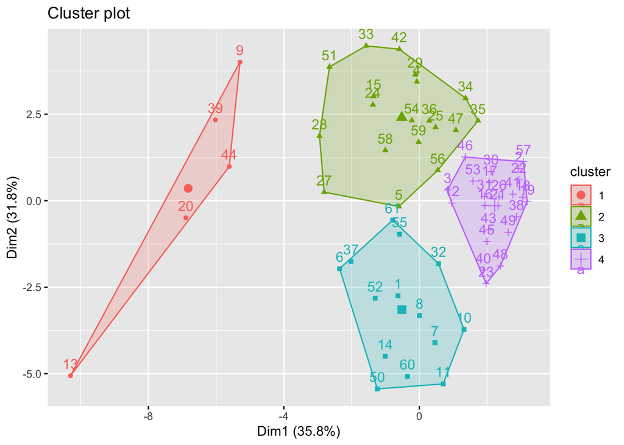

```r
# 可视化
fviz_cluster(final_cluster, data = normalized_data)
```

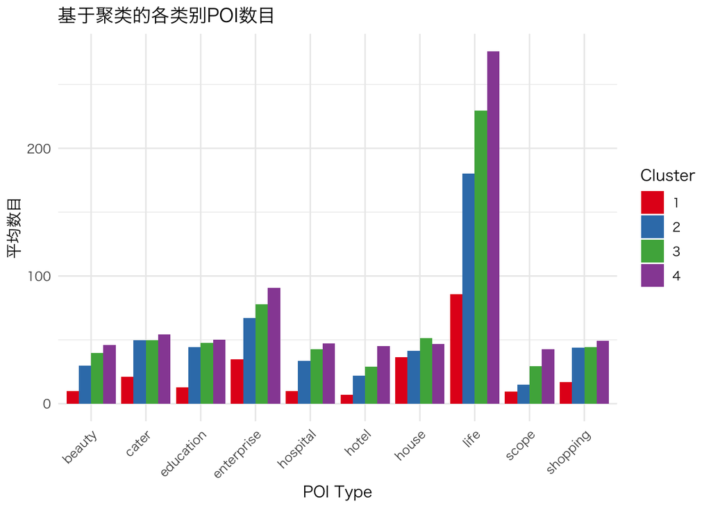

```r
# 每个聚类中每种POI类型的平均数目
poi_averages <- store_features %>%
  group_by(cluster) %>%
  summarise(across(starts_with("count_"), mean, na.rm = TRUE)) %>%
  pivot_longer(cols = starts_with("count_"), names_to = "poi_type", values_to = "average_count")

# 修正POI类型的名称，去掉前缀以简化显示
poi_averages$poi_type <- sub("count_", "", poi_averages$poi_type)

# 绘制柱状图
ggplot(poi_averages, aes(x = poi_type, y = average_count, fill = as.factor(cluster))) +
  geom_bar(stat = "identity", position = position_dodge()) +
  scale_fill_brewer(palette = "Set1", name = "Cluster") +
  labs(title = "基于聚类的各类别POI数目",
       x = "POI Type",
       y = "平均数目") +
  theme_minimal() +
  theme(text = element_text(family = "Hiragino Sans GB"),
        axis.text.x = element_text(angle = 45, hjust = 1))
```

推测这种情况的原因是： 1. POI过少可能和商圈热度不高有关 2. POI过多时形成竞争，影响销量

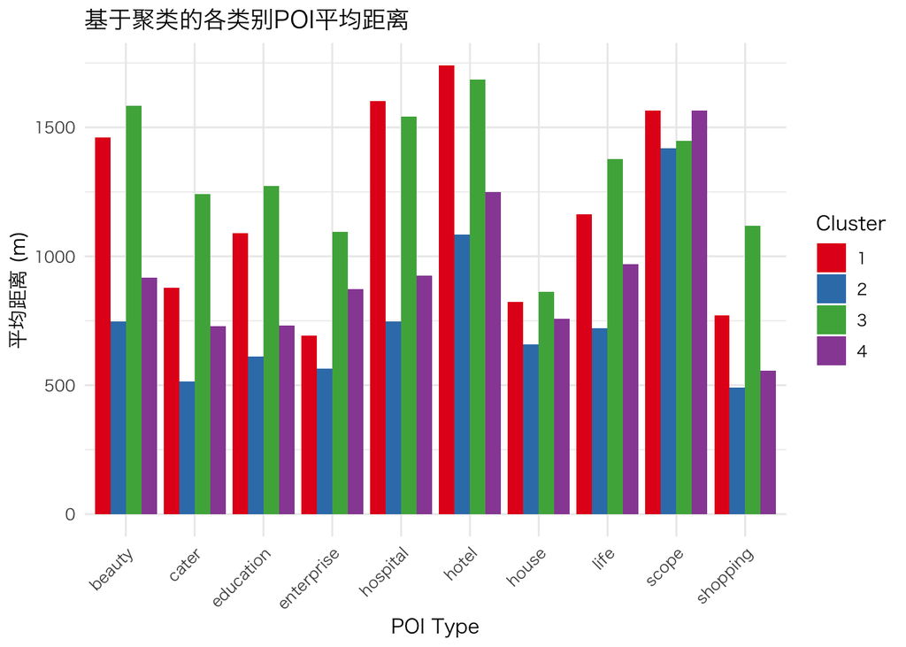

```r
# 每个聚类中每种POI类型的平均距离
poi_distance_averages <- store_features %>%
  group_by(cluster) %>%
  summarise(across(starts_with("poi_distance_"), mean, na.rm = TRUE)) %>%
  pivot_longer(cols = starts_with("poi_distance_"), names_to = "poi_type", values_to = "average_distance")

poi_distance_averages$poi_type <- sub("poi_distance_", "", poi_distance_averages$poi_type)

ggplot(poi_distance_averages, aes(x = poi_type, y = average_distance, fill = as.factor(cluster))) +
  geom_bar(stat = "identity", position = position_dodge()) +
  scale_fill_brewer(palette = "Set1", name = "Cluster") +
  labs(title = "基于聚类的各类别POI平均距离",
       x = "POI Type",
       y = "平均距离 (m)") +
  theme_minimal() +
  theme(text = element_text(family = "Hiragino Sans GB"),
        axis.text.x = element_text(angle = 45, hjust = 1))
```

聚类分析仍然相对笼统，下面我们采取机器学习的方法，试图建立预测模型，从而更好地指导新店选址。

## 建立预测模型

很明显我们需要拟合的关系并非线性，这里我们选用决策树模型。

```r
library(rpart)
library(rpart.plot)
```

使用随机抽样的方式将数据集分割为训练集和验证集，比例分别为70%和30%。另外需要去除店名和之前聚类分析得到的cluster，前者与预测无关，后者会对预测产生不应有的影响。

```r
set.seed(123)  # 设置随机种子

quantiles <- quantile(store_features$Comments_Num, probs = c(0.25, 0.5, 0.75), na.rm = TRUE)

# 使用cut函数进行分组
store_features$comments_num_group <- cut(store_features$Comments_Num,
                breaks = c(0, quantiles[1], quantiles[2], quantiles[3], 5000, 10000, Inf),
                labels = c("1", "2", "3", "4", "5", "6"),
                include.lowest = TRUE)

# 查看分组结果
table(store_features$comments_num_group)
```

```
##
##  1  2  3  4  5  6
## 16 15 15  9  4  2
```

```r
# 去除店名和cluster两列
store_features <- store_features %>%
  select(-name, -cluster)

# 计算训练集的大小
train_size <- floor(0.7 * nrow(store_features))

# 创建随机排列以分割数据集
train_indices <- sample(seq_len(nrow(store_features)), size = train_size)

# 分割数据集
train_data <- store_features[train_indices, ]
test_data <- store_features[-train_indices, ]
```

接下来建立模型并进行预测

```r
# 构建决策树模型
tree_model <- rpart(comments_num_group ~ ., data = train_data, method = "class")

# 在验证集上使用模型进行预测
predictions <- predict(tree_model, newdata = test_data)
predicted_classes <- max.col(predictions, ties.method = "first")
actuals <- test_data$comments_num_group
```

最后检验模型效果

```r
library(caret)
# 需要将预测类别和实际类别转换为因子类型，并确保它们有相同的水平
predicted_classes <- factor(predicted_classes, levels = unique(actuals))
actuals <- factor(actuals, levels = unique(actuals))

# 计算混淆矩阵
conf_matrix <- confusionMatrix(predicted_classes, actuals)

# 打印混淆矩阵
print(conf_matrix$table)
```

```
##           Reference
## Prediction 1 6 3 2 4
##          1 2 0 0 0 0
##          6 0 0 0 0 0
##          3 0 0 5 0 0
##          2 1 0 0 6 0
##          4 0 1 0 0 4
```

```r
# 提取各项指标
accuracy <- conf_matrix$overall['Accuracy']
precision <- conf_matrix$byClass['Precision']
recall <- conf_matrix$byClass['Recall']
F1 <- conf_matrix$byClass['F1']

# 打印结果
print(paste("Accuracy:", accuracy))
```

```
## [1] "Accuracy: 0.894736842105263"
```

```r
print(paste("Precision:", precision))
```

```
## [1] "Precision: NA"
```

```r
print(paste("Recall:", recall))
```

```
## [1] "Recall: NA"
```

```r
print(paste("F1 Score:", F1))
```

```
## [1] "F1 Score: NA"
```

精确率和召回率为`NA`是因为有些类别根本没有正例，导致分母为零。假如忽略没有正例的类别6，并按支持度加权，所得精确率为0.8947，召回率为0.9474，F1分数为0.9203.

从上面的数据可以看出模型的预测效果比较好，若想在某处增加新店，可以根据该位置POI数据和模型预测销量。

## 总结及心得

### 分析成果

以上的分析主要有以下几个方面的成果：

1.针对各项属性进行了总结，展示了消费，位置，评论数等的分布

2.着重于评论数（作为销量的代理指标），POI的类别、距离进行了聚类分析，发现了销量与POI类别以及距离的关系

3.利用机器学习建立了基于决策树的预测模型，给定各个POI类型的数目以及平均距离，预测销量。经检验模型预测效果较好，可作为新店选址的依据。

### 心得体会

数据分析的实操过程比预想中要多很多困难，包括数据预处理，模型建立等。例如处理数据时为了后续分析需要转换为独热向量，最初选取的特征较多，也没有很好的处理`NA`值，后来经多次摸索，保留了关系较大的特征。

另外在分析过程中也尝试过一些其他手段，例如Apriori算法挖掘频繁项集。这是挖掘属性间关系的一种有效手段，但算法始终无法正常运行，遂放弃。另外也尝试了利用支持向量机(SVM)进行拟合，因为这种模型在中小型数据集上表现良好，适合这里的数据（只有几十家门店），但因为某些我未能发现的原因，实际运行的准确度很低，参数优化也未能收敛，因此也没有采用。

总的来说，利用R语言进行数据分析的技术得到了提升。以往的数据分析几乎都是使用Python，通过这门课程以及上面的数据分析过程，掌握了一种不同的分析工具。